# E-Commerce Analytics- A Deep-Dive into Channel ROI and Customer Segments

### 1. Project Overview

This project provides a comprehensive data-driven review of an e-commerce platform's performance throughout 2024. By merging customer behavior, session intent, and marketing expenditure, this analysis identifies critical bottlenecks in the conversion funnel and uncovers significant misallocations in marketing spend.

### 2. Problem Statement

Despite consistent traffic volume, the platform is facing three primary challenges:

Stagnant Efficiency: Marketing spend is high, but the correlation between investment and revenue return appears to be weakening in primary channels.

Funnel Leakage: High "window shopping" behavior on the mobile app is resulting in significant drop-offs before the checkout stage.

High Acquisition Costs: The cost to acquire new users (CAC) currently outweighs their initial transaction value, making long-term retention the only path to profitability.

### 3. Analytical Objectives

KPI Tracking: Visualize monthly GMV trends and establish a baseline for "normal" performance versus seasonal peaks.

Conversion Audit: Map the user journey from landing to purchase across different acquisition channels.

Marketing ROI: Identify "Star" channels versus "Underperformers" using dual-axis efficiency modeling.

Segmentation: Quantify the revenue impact of High-Value customers to prioritize retention efforts.

## Step 1: Environment Setup & Data Loading

*Imports necessary libraries and loads raw datasets.*

```python
import pandas as pd
import numpy as np

import matplotlib.pyplot as plt
import seaborn as sns

pd.set_option("display.max_columns", None)
sns.set_style("whitegrid")
```

```python
customers = pd.read_csv(r"C:customers.csv")
marketing = customers = pd.read_csv(r"C:marketing_spend.csv")
orders = customers = pd.read_csv(r"C:orders.csv")
sessions = customers = pd.read_csv(r"C:sessions.csv")
monthlyperf = customers = pd.read_csv(r"C:Monthly_Channel_Performance_Data.csv")
```

**Summary:** Data is loaded from CSV files. We are working with Customer, Session, Order, and Marketing Spend logs.

### Data Integrity Check

*Identifying missing values and dataset dimensions.*

```python
print(customers.isnull().sum())
print(sessions.isnull().sum())
print(orders.isnull().sum())
print(marketing.isnull().sum())
```

```
session_id       0
customer_id      0
channel          0
viewed           0
added_to_cart    0
ordered          0
dtype: int64
session_id       0
customer_id      0
channel          0
viewed           0
added_to_cart    0
ordered          0
dtype: int64
order_id                 0
customer_id              0
order_date               0
category                 0
order_value              0
delivery_time_minutes    0
dtype: int64
date           0
channel        0
spend          0
impressions    0
clicks         0
dtype: int64
```

```python
print(customers.shape, sessions.shape, orders.shape, marketing.shape)
```

```
(5000, 6) (5000, 6) (2800, 6) (365, 5)
```

**Conclusion:** Data is clean with no missing values. Dataset sizes are consistent for analysis.

# Part 1: Executive KPI & Monthly GMV Trends

*This section establishes the baseline business performance and identifies growth trends.*

### 1.1: GMV Calculation & Executive Summary

*Calculating Total GMV, AOV, and Total Orders.*

```python
# 2. Data Cleaning: Convert dates
orders['order_date'] = pd.to_datetime(orders['order_date'])
```

```python
# 3. Calculate Executive KPIs
total_gmv = orders['order_value'].sum()
total_orders = len(orders)
aov = total_gmv / total_orders
unique_customers = orders['customer_id'].nunique()
```

### 1.2: Monthly Trend Analysis

*Visualizing performance fluctuations across 2024.*

```python
# 4. Monthly Trend Analysis
orders['month_year'] = orders['order_date'].dt.to_period('M') #remove date and keep the month and order months
monthly_kpis = orders.groupby('month_year').agg(
    monthly_gmv=('order_value', 'sum'),
    order_count=('order_id', 'count')
).reset_index()
monthly_kpis['month_year'] = monthly_kpis['month_year'].astype(str)
```

```python
# 1. Group by Period first (to keep things sorted chronologically)
monthly_kpis = orders.groupby(orders['order_date'].dt.to_period('M')).agg(
    monthly_gmv=('order_value', 'sum'),
    order_count=('order_id', 'count')
).reset_index()

# 2. Convert the 'order_date' (index 0) to the pretty format "Jan-24"
# %b = Short month name (Jan), %y = Two-digit year (24)
monthly_kpis['month_display'] = monthly_kpis['order_date'].dt.strftime('%b-%y')

# 3. View the result
print(monthly_kpis[['month_display', 'monthly_gmv', 'order_count']].head())
```

```
  month_display  monthly_gmv  order_count
0        Jan-24      7874.13          251
1        Feb-24      6258.25          220
2        Mar-24      7295.59          236
3        Apr-24      7234.80          250
4        May-24      6794.76          228
```

**Trend Insight:** Performance peaked in January and August. The October slump is a critical observation for inventory planning.

# Part 2: Conversion Funnel & Channel Health

*Analyzing the user journey from landing to purchase across different channels.*

### 2.1: Platform-wide Conversion Funnel

*Mapping 'View' to 'Cart' to 'Order' transitions.*

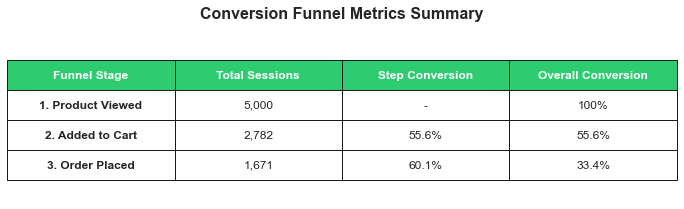

```python
# 1. Load data
sessions = pd.read_csv(r"C:\Users\anees\OneDrive\Desktop\Python\Ecommerce Analytics\sessions.csv")

# 2. Calculate counts
viewed = sessions['viewed'].sum()
cart = sessions['added_to_cart'].sum()
ordered = sessions['ordered'].sum()

# 3. Create DataFrame for the table
data = {
    "Funnel Stage": ["1. Product Viewed", "2. Added to Cart", "3. Order Placed"],
    "Total Sessions": [f"{viewed:,}", f"{cart:,}", f"{ordered:,}"],
    "Step Conversion": ["-", f"{(cart/viewed)*100:.1f}%", f"{(ordered/cart)*100:.1f}%"],
    "Overall Conversion": ["100%", f"{(cart/viewed)*100:.1f}%", f"{(ordered/viewed)*100:.1f}%"]
}
df_funnel = pd.DataFrame(data)

# 4. Create a professional table image using Matplotlib
fig, ax = plt.subplots(figsize=(10, 3))
ax.axis('off') # Hide axes

# Create the table
table = ax.table(cellText=df_funnel.values,
                 colLabels=df_funnel.columns,
                 cellLoc='center',
                 loc='center',
                 colColours=["#2ecc71"] * 4) # Noon-style green for headers

# Styling the table
table.auto_set_font_size(False)
table.set_fontsize(12)
table.scale(1.2, 2.5) # Scale height and width

# Make headers bold and white
for (row, col), cell in table.get_celld().items():
    if row == 0:
        cell.get_text().set_weight('bold')
        cell.get_text().set_color('white')
    if row > 0 and col == 0:
        cell.get_text().set_weight('bold')

plt.title("Conversion Funnel Metrics Summary", fontsize=16, fontweight='bold', pad=20)
plt.savefig('funnel_table_bordered.png', bbox_inches='tight', dpi=300)
```

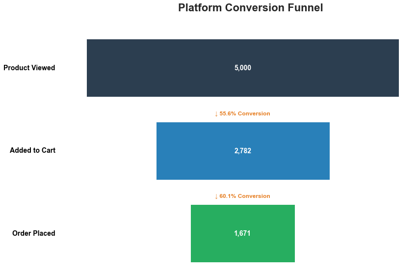

```python
import pandas as pd
import matplotlib.pyplot as plt

# 1. Calculate counts again
sessions = pd.read_csv(r"C:\Users\anees\OneDrive\Desktop\Python\Ecommerce Analytics\sessions.csv")
counts = [
    sessions['viewed'].sum(),
    sessions['added_to_cart'].sum(),
    sessions['ordered'].sum()
]
phases = ['Product Viewed', 'Added to Cart', 'Order Placed']

# 2. Plotting with explicit labels
fig, ax = plt.subplots(figsize=(12, 8))

max_count = counts[0]
left_offsets = [(max_count - count) / 2 for count in counts]
colors = ['#2c3e50', '#2980b9', '#27ae60']

# Create bars
bars = ax.barh(phases[::-1], counts[::-1], left=left_offsets[::-1], color=colors[::-1], height=0.7)

# 3. Add Labels - Fix: Explicitly labeling the Y-axis and adding text
for i, count in enumerate(counts):
    y_pos = 2 - i

    # Label 1: The Phase Name (on the left)
    ax.text(-500, y_pos, phases[i], ha='right', va='center', fontsize=14, fontweight='bold', color='black')

    # Label 2: The Count (inside the bar)
    ax.text(max_count / 2, y_pos, f"{count:,}", ha='center', va='center', color='white', fontweight='bold', fontsize=14)

    # Label 3: Conversion Rates
    if i > 0:
        conversion = (count / counts[i-1]) * 100
        ax.text(max_count / 2, y_pos + 0.45, f"â†“ {conversion:.1f}% Conversion", ha='center', va='center', color='#e67e22', fontweight='bold', fontsize=12)

ax.set_title('Platform Conversion Funnel', fontsize=22, fontweight='bold', pad=40, va= 'center', ha='center')
#ax.set_xlim(-1500, max_count + 500) # space for labels - not needed
ax.axis('off')

plt.tight_layout()
plt.savefig('funnel_chart_labeled.png')
```

### 2.2: Channel Strategic Quadrant

*Classifying channels based on Interest (X-axis) and Intent (Y-axis).*

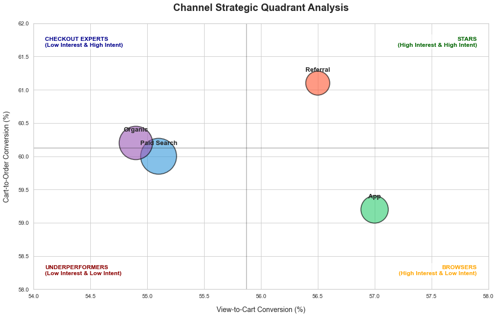

```python
import pandas as pd
import matplotlib.pyplot as plt
import seaborn as sns

# Data from previous analysis
data = {
    'channel': ['Referral', 'App', 'Paid Search', 'Organic'],
    'Total_Sessions': [773, 1002, 1729, 1496],
    'View_to_Cart_%': [56.5, 57.0, 55.1, 54.9],
    'Cart_to_Order_%': [61.1, 59.2, 60.0, 60.2]
}
df_bubble = pd.DataFrame(data)

# Setup Plot
plt.figure(figsize=(14, 9))
sns.set_theme(style="whitegrid")

# Create Bubble Chart
# Size based on sessions
scatter = plt.scatter(
    x=df_bubble['View_to_Cart_%'],
    y=df_bubble['Cart_to_Order_%'],
    s=df_bubble['Total_Sessions'] * 3,
    c=['#FF5733', '#2ecc71', '#3498db', '#9b59b6'],
    alpha=0.6,
    edgecolors="black",
    linewidth=2
)

# Set Axis Limits to provide space for quadrant labels inside the chart
x_min, x_max = 54.0, 58.0
y_min, y_max = 58.0, 62.0
plt.xlim(x_min, x_max)
plt.ylim(y_min, y_max)

# Calculate Quadrant Crossing Points (Means)
x_mean = df_bubble['View_to_Cart_%'].mean()
y_mean = df_bubble['Cart_to_Order_%'].mean()

# Add Quadrant Lines
plt.axvline(x=x_mean, color='black', linestyle='-', alpha=0.3)
plt.axhline(y=y_mean, color='black', linestyle='-', alpha=0.3)

# Add Channel Name Labels (near the bubbles)
for i in range(df_bubble.shape[0]):
    plt.text(
        df_bubble['View_to_Cart_%'][i],
        df_bubble['Cart_to_Order_%'][i] + 0.15,
        df_bubble['channel'][i],
        ha='center', va='bottom', fontsize=13, fontweight='bold'
    )

# --- SHIFTING QUADRANT LABELS INSIDE THE CHART ---
# Top Right
plt.text(x_max - 0.1, y_max - 0.2, "STARS\n(High Interest & High Intent)",
         ha='right', va='top', fontsize=12, fontweight='bold', color='darkgreen',
         bbox=dict(facecolor='white', alpha=0.6, edgecolor='none'))

# Top Left
plt.text(x_min + 0.1, y_max - 0.2, "CHECKOUT EXPERTS\n(Low Interest & High Intent)",
         ha='left', va='top', fontsize=12, fontweight='bold', color='darkblue',
         bbox=dict(facecolor='white', alpha=0.6, edgecolor='none'))

# Bottom Right
plt.text(x_max - 0.1, y_min + 0.2, "BROWSERS\n(High Interest & Low Intent)",
         ha='right', va='bottom', fontsize=12, fontweight='bold', color='orange',
         bbox=dict(facecolor='white', alpha=0.6, edgecolor='none'))

# Bottom Left
plt.text(x_min + 0.1, y_min + 0.2, "UNDERPERFORMERS\n(Low Interest & Low Intent)",
         ha='left', va='bottom', fontsize=12, fontweight='bold', color='darkred',
         bbox=dict(facecolor='white', alpha=0.6, edgecolor='none'))

# Formatting
plt.title('Channel Strategic Quadrant Analysis', fontsize=20, fontweight='bold', pad=25)
plt.xlabel('View-to-Cart Conversion (%)', fontsize=14, labelpad=15)
plt.ylabel('Cart-to-Order Conversion (%)', fontsize=14, labelpad=15)

plt.tight_layout()
plt.savefig('quadrant_chart_fixed_labels.png')
```

**Strategic Insight:** Referral is the 'Star' channel. The App brings in high interest ('Browsers') but requires retargeting to push users toward checkout.

# Part 3: Marketing ROI & Efficiency

*Auditing spend vs. revenue to identify the most profitable acquisition channels.*

### 3.1: Spend vs. Revenue (Dual Axis)

*Comparing investment and return on independent scales.*

[figure not shown]

```python
import pandas as pd
import matplotlib.pyplot as plt
import seaborn as sns

# 1. Prepare Data
orders = pd.read_csv(r"C:\Users\anees\OneDrive\Desktop\Python\Ecommerce Analytics\orders.csv")
orders['order_date'] = pd.to_datetime(orders['order_date'])
month_period = orders['order_date'].dt.to_period('M')

# Data for Bars (Categories) and Line (Total)
category_dist = orders.groupby([month_period, 'category'])['order_value'].sum().unstack().fillna(0)
monthly_total = orders.groupby(month_period)['order_value'].sum()
display_months = category_dist.index.strftime('%b-%y')

# 2. Setup Plot
sns.set_theme(style="whitegrid")
fig, ax = plt.subplots(figsize=(20, 8))

# A. Plot Stacked Bars (Distribution)
category_dist.index = display_months
category_dist.plot(kind='bar', stacked=True, ax=ax, color=['#FF5733', '#2ecc71', '#3498db'], alpha=0.7)

# B. Plot Line (Total Trend)
# 'range(len(display_months))' ensures the line points align with the center of the bars
ax.plot(range(len(display_months)), monthly_total.values, marker='o', color='Grey', linewidth=3, label='Total GMV')

# Axis titles
ax.set_xlabel('Month', fontsize=14, labelpad=15, fontweight='bold')
ax.set_ylabel('Total GMV (AED)', fontsize=14, labelpad=15, fontweight='bold')

# C. Plot Dotted Average Line
avg_gmv = monthly_total.mean()
ax.axhline(avg_gmv, color='red', linestyle='--', linewidth=1.5, label=f'Avg GMV ({avg_gmv:,.0f} AED)')

# 3. Add Labels & Formatting
for i, val in enumerate(monthly_total.values):
    ax.text(i, val + 200, f'{int(val):,}', ha='center', fontweight='bold', color='black')

ax.set_title('Executive Dashboard: GMV Trend & Category Mix (2024)', fontsize=18, fontweight='bold', pad=25)
ax.legend(loc='upper center', bbox_to_anchor=(0.5, -0.18), ncol=5,
          title='Metrics & Categories', title_fontsize='12', fontsize='11')
plt.xticks(rotation=30)


plt.subplots_adjust(bottom=0.18, right=0.8)
plt.show()
```

[output not shown]

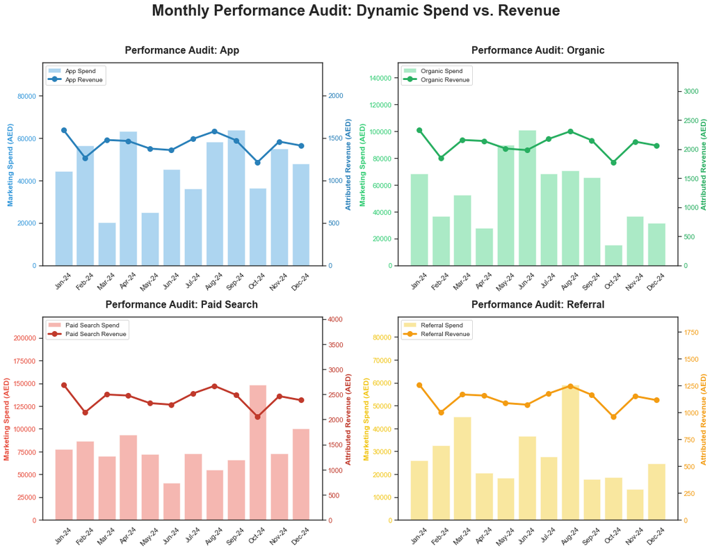

```python
# 1. Re-calculate actual monthly fluctuations from original sources
try:

    # Data Preparation
    orders['month_period'] = pd.to_datetime(orders['order_date']).dt.to_period('M')
    monthly_revenue_raw = orders.groupby('month_period')['order_value'].sum()
    channel_shares = sessions.groupby('channel')['ordered'].sum() / sessions['ordered'].sum()
    marketing['month_period'] = pd.to_datetime(marketing['date']).dt.to_period('M')
    monthly_spend_raw = marketing.groupby(['month_period', 'channel'])['spend'].sum().reset_index()

    # 2. Setup 2x2 Grid with unique colors per channel
    sns.set_theme(style="white")
    fig, axes = plt.subplots(2, 2, figsize=(16, 12))
    axes = axes.flatten()

    channels = ['App', 'Organic', 'Paid Search', 'Referral']
    # Unique color palettes for each channel
    # Format: (Bar Color, Line Color)
    channel_colors = {
        'App': ('#3498db', '#2980b9'),          # Blues
        'Organic': ('#2ecc71', '#27ae60'),      # Greens
        'Paid Search': ('#e74c3c', '#c0392b'),  # Reds
        'Referral': ('#f1c40f', '#f39c12')      # Yellows/Oranges
    }

    for i, channel in enumerate(channels):
        ax1 = axes[i]
        c_data = monthly_spend_raw[monthly_spend_raw['channel'] == channel].sort_values('month_period')

        # Match revenue to the same months as spend
        months_str = c_data['month_period'].dt.strftime('%b-%y')
        revenue_trend = [monthly_revenue_raw.get(m, 0) * channel_shares[channel] for m in c_data['month_period']]

        bar_color, line_color = channel_colors[channel]

        # PRIMARY AXIS: Spend (Bars)
        ax1.bar(months_str, c_data['spend'], color=bar_color, alpha=0.4, label=f'{channel} Spend')
        ax1.set_ylabel('Marketing Spend (AED)', color=bar_color, fontweight='bold')
        ax1.tick_params(axis='y', labelcolor=bar_color)
        ax1.set_title(f'Performance Audit: {channel}', fontsize=16, fontweight='bold', pad=15)
        ax1.tick_params(axis='x', rotation=45)

        # SECONDARY AXIS: Revenue (Line)
        ax2 = ax1.twinx()
        ax2.plot(months_str, revenue_trend, color=line_color, marker='o', linewidth=3, markersize=8, label=f'{channel} Revenue')
        ax2.set_ylabel('Attributed Revenue (AED)', color=line_color, fontweight='bold')
        ax2.tick_params(axis='y', labelcolor=line_color)

        # SYNCING: Ensure real trends are visible and distinct
        ax1.set_ylim(0, c_data['spend'].max() * 1.5)
        ax2.set_ylim(0, max(revenue_trend) * 1.5)

        # Legend
        lines1, labels1 = ax1.get_legend_handles_labels()
        lines2, labels2 = ax2.get_legend_handles_labels()
        ax1.legend(lines1 + lines2, labels1 + labels2, loc='upper left', fontsize=10, frameon=True)

    plt.suptitle('Monthly Performance Audit: Dynamic Spend vs. Revenue', fontsize=24, fontweight='bold', y=1.02)
    plt.tight_layout()
    plt.savefig('channel_audit_color_coded.png')
    print("Multi-color audit charts generated successfully.")

except Exception as e:
    print(f"Error: {e}")
```

# Part 4: Customer Segmentation

*Analyzing the revenue contribution of High Value, Repeat, and New customers.*

### 4.1: Segment Performance Audit

*Breaking down ARPU and AOV by customer tier.*

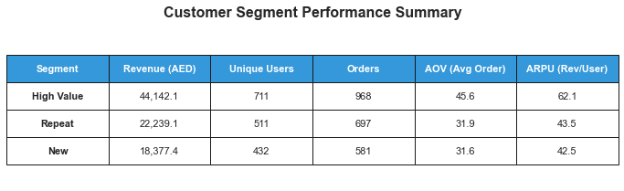

```python
import pandas as pd
import matplotlib.pyplot as plt

# 1. Prepare the Data
data = {
    'Segment': ['High Value', 'Repeat', 'New'],
    'Revenue (AED)': [44142.1, 22239.1, 18377.4],
    'Unique Users': [711, 511, 432],
    'Orders': [968, 697, 581]
}
df = pd.DataFrame(data)

# 2. Calculate Strategic KPIs
df['AOV (Avg Order)'] = (df['Revenue (AED)'] / df['Orders']).map('{:.1f}'.format)
df['ARPU (Rev/User)'] = (df['Revenue (AED)'] / df['Unique Users']).map('{:.1f}'.format)
df['Revenue (AED)'] = df['Revenue (AED)'].map('{:,.1f}'.format)

# 3. Create the Styled Table Image
fig, ax = plt.subplots(figsize=(12, 3))
ax.axis('off')

# Blue branding for the Customer Segmentation section
header_color = "#3498db"

table = ax.table(cellText=df.values,
                 colLabels=df.columns,
                 cellLoc='center',
                 loc='center',
                 colColours=[header_color] * len(df.columns))

table.auto_set_font_size(False)
table.set_fontsize(11)
table.scale(1, 2.5) # Stretch height for professional look

# Bold headers and first column
for (row, col), cell in table.get_celld().items():
    if row == 0:
        cell.get_text().set_weight('bold')
        cell.get_text().set_color('white')
    if col == 0:
        cell.get_text().set_weight('bold')

plt.title("Customer Segment Performance Summary", fontsize=16, fontweight='bold', pad=20)
plt.show()
```

**Segmentation Insight:** 52% of revenue is driven by a core group of High-Value 'whales.' Protecting this tier with loyalty rewards is essential for platform stability.

# Final Executive Summary

# Final Strategic Action Plan: Data-Driven Recommendations

### 1. Inventory & Campaign Scheduling (Part 1 Insights)

Replicate High-Velocity Months: Analyze the specific promotional mix used in January and August to create a "Success Blueprint" for lower-performing periods.

The "October Rescue" Plan: Launch aggressive mid-quarter clearance or loyalty-only sales in October to mitigate the historical revenue slump observed in the data.

### 2. Conversion Funnel Optimization (Part 2 Insights)

UI/UX Leakage Repair: Focus engineering efforts on the "View-to-Cart" stage. Reducing friction here (e.g., implementing one-click "Add to Cart" from the search results page) would have the highest impact on the bottom line.

### 3. Marketing Budget Reallocation (Part 3 Insights)

Scale the "Star" Channel: Reinvest those savings into Referral and Organic initiatives. Specifically, launch an "Influencer Referral Program" to capitalize on the high-intent traffic these channels already provide at a lower cost.

### 4. Customer Retention & LTV Strategy (Part 4 Insights)

Whale Protection Program: Since 52% of revenue comes from the "High Value" segment, establish a VIP Tier with exclusive benefits (e.g., early access, free express shipping) to prevent churn in this critical group.

Bridging the Repeat Gap: The data shows "Repeat" users don't spend significantly more than "New" users. Implement Upsell/Cross-sell algorithms at checkout specifically for repeat buyers to increase their Average Order Value (AOV) toward the "High Value" benchmark of 45.6 AED.

#### If you're looking for someone to help bridge the gap between technical data systems and executive-level decision-making or just want to talk analytics, feel free to reach out to me at -

LinkedIn - www.linkedin.com/in/aneeshkulkarni11

Mail - aneeshkulkarni1@gmail.com